# The Control Polygon Reduction Package

Peter DeWitt

2023-11-29

The cpr package provides several tools for finding parsimonious B-spline regression models via control polygon reduction. This vignette is an overview of the tools provided by the package.

This vignette is not complete. The details will be filled in soon. As for now, this is a placeholder for many topics to come. A Journal of Statistical Software paper is under development. That paper will become the foundation for this vignette.

A brief overview of the Control Polygon Reduction and Control Net Reduction method for finding parsimonious B-spline regression models are presented first. The later sections of this vignette provide extended detail on the additional tools provided by the cpr package.

```r
# Needed packages to run the examples in this vignette
library(cpr)
library(splines)
```

# CPR: Control Polygon Reduction

*Coming Soon* A full description of the CPR method, including the background on B-splines and assessing knot influence will be provided soon.

The quick overview: for a uni-variable B-spline regression model
$$\boldsymbol{y}= f(\boldsymbol{x}) +
\boldsymbol{Z}_{f} \boldsymbol{\beta} + \boldsymbol{Z}_{r}
\boldsymbol{b} + \epsilon$$
where $\boldsymbol{y}$ is a function of one variable $x$ with other (optional) fixed effects $\boldsymbol{Z}_{f} \beta$ and (optional) random effects $\boldsymbol{Z}_{r} \boldsymbol{b},$ we are interested in modeling the function $f\left( \boldsymbol{x} \right)$ with B-splines.

The B-spline function is
$$f
\left(\boldsymbol{x}\right) \approx \boldsymbol{B}_{k, \boldsymbol{\xi}}
\left( \boldsymbol{x} \right) \boldsymbol{\theta}$$
were $\boldsymbol{B}$ is the basis matrix defined by the polynomial order $k$ and knot sequence $\boldsymbol{\xi},$ and the regression coefficients $\boldsymbol{\theta}.$

The Control Polygon Reduction (CPR) approach to finding parsimonious regression models with a good quality of fit is to start with a high cardinal knot sequence, assess the relative influence of each knot on the spline function, remove the least influential knot, refit the regression model, reassess the relative influence of each knot, and so forth until all knots knots have been removed. The selection of a regression model is made by looking at the regression models of sequentially larger knot sequences until it is determined that the use of an additional knot does not provide any meaningful improvements to the regression model.

There are only four steps that the end user needs to take to use the CPR algorithm within the cpr package.

1. Construct a control polygon with a large cardinal knot sequence, using `cp`.
2. Run the CPR algorithm via a call to `cpr`.
3. Use diagnostic plots to determine the preferable model.
4. Save the preferable model.

Here is an example.

```r
# Construct the initial control polygon
initial_cp <- cp(log10(pdg) ~ bsplines(day, df = 54), data = spdg)

# Run CPR
cpr_run    <- cpr(initial_cp)
```

There are two types of diagnostic plots, 1) sequential control polygons, and 2) root mean squared error (RMSE) by model index.

In the plot below, there is no major differences in the shape of the control polygon between model index 4, 5, and 6. As such, we would conclude that model index 4 is sufficient for modeling the data.

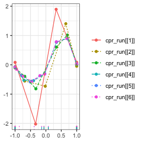

```r
# sequential control polygons
plot(cpr_run, color = TRUE)
```

Further, in the plot below, we see that there is very little improvement in the RMSE from model index 4 to 5, and beyond. As with the plot above, we conclude that model index 4 is sufficient for modeling the data.

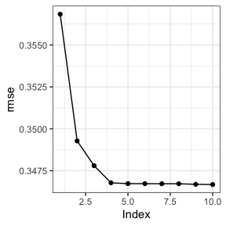

```r
# RMSE by model index
plot(cpr_run, type = 'rmse', to = 10)
```

Extract the model. To save memory when running CPR, the default is to omit the regression model objects from the control polygons with in the `cpr_run` object. To get the regression model back, you can extract the knot locations and build the model yourself, or update the `selected_cp` object to retain the fit.

```r
selected_cp <- cpr_run[[4]]
selected_cp$iknots
## [1] -0.13707050 -0.05931285  0.08270488
```

```r
selected_cp <- update(selected_cp, keep_fit = TRUE)
selected_fit <- selected_cp$fit
coef_matrix <- summary(selected_fit)$coef
dimnames(coef_matrix)[[1]] <- paste("Vertex", 1:7)
coef_matrix
##             Estimate  Std. Error    t value      Pr(>|t|)
## Vertex 1 -0.06976405 0.009753699  -7.152574  8.754631e-13
## Vertex 2 -0.52625841 0.019710942 -26.698796 7.785245e-155
## Vertex 3 -0.53951851 0.018119130 -29.776181 1.965406e-191
## Vertex 4 -0.30001235 0.009170159 -32.716156 7.645099e-230
## Vertex 5  0.76626123 0.018951665  40.432397  0.000000e+00
## Vertex 6  0.90537608 0.019307858  46.891587  0.000000e+00
## Vertex 7  0.02638169 0.009757316   2.703786  6.860157e-03
```

If you wanted to run this analysis with a better modeling approach, e.g., using mixed effect models handle the multiple observations within a subject, you can specify the regression approach via the `method` argument in the `cp` call.

```r
library(lme4)
initial_lmer_cp <- cp(log10(pdg) ~ bsplines(day, df = 54) + (1 | id),
                      data = spdg,
                      method = lmer)
```

# CNR: Control Net Reduction

*Coming Soon* Control Net reduction is the natural extension of CPR from uni-variable functions to multi-variable functions. Details on this work will be added to this vignette soon.

# Additional Tools

The CPR and CNR algorithms rely on B-splines, control polygons, tensor products of B-splines, and control nets. The following sections provide additional detail on the tools within the cpr package.

## B-Splines

Base R includes the splines package and the `splines::bs` call for building B-splines. The cpr package provides the `cpr::bsplines` call as there are certain default behaviors and additional required meta-data storage requirements needed for the CPR method that the `splines::bs` call does not provide. In this section we compare `splines::bs` and `cpr::bsplines` so that end users can translate between the two functions.

|  | `splines::bs` | `cpr::bsplines` |
| --- | --- | --- |
| Arguments |  |  |
|  | `x` | `x` |
|  | `df` | `df` |
|  | `knots` | `iknots` |
|  | `degree = 3` | `order = 4L` |
|  | `Boundary.knots = range(x)` | `bknots = range(x)` |
|  | `intercept = FALSE` | – |
| Attributes |  |  |
|  | `dim` | `dim` |
|  | `degree` | `order` |
|  | `knots` | `iknots` |
|  | `Boundary.knots` | `bknots` |
|  | `intercept` | – |
|  | – | `xi` |
|  | – | `xi_star` |
|  | `class` | `class` |

A major difference between the two functions is related to the `intercept` argument of `bs`. By default, `bs` will omit the first column of the basis whereas `bsplines` will return the whole basis. The omission of the first column of the basis generated by `bs` allows for additive `bs` calls to be used on the right-hand-side of a regression formula and generate a full rank design matrix. If additive `bsplines` calls, or additive `bs` with `intercept = TRUE`, are on the right-hand-side of the regression equation the resulting design matrix will be rank deficient. This is a result of the B-splines being a partition of unity. As the CPR algorithm is based on having the whole basis, the `bsplines` function is provided to make it easy to work with the whole basis without having to remember to use non-default settings in `bs`.

Both functions use `x`, a numeric vector, as the first argument. The degrees of freedom, `df`, argument is slightly different between the two functions; the return object from `bs` depends on the values of `df` and `intercept` whereas `bsplines` always returns the full basis and thus `df` will be equal the number of columns of the returned basis.

`bs` uses the polynomial `degree` whereas `bsplines` uses the polynomial `order` (order = degree + 1) to define the splines. The default for both `bs` and `bsplines` is to generate cubic B-splines.

Specifying the internal knots and boundary knots are the same between the two functions save the name of the arguments. For both `bs` and `bsplines` only the degrees of freedom or the internal knots need to be specified. If the end user specifies both, the specified knots take precedence. If only the degrees of freedom are specified then `bs` will generate internal knots via a call equivalent to

```
stats::quantile(x, probs = seq(0, 1, length = length(knots) + 2L)[-c(1, length(knots) + 2L)].
```

The default behavior for `bsplines` is nearly the same, only that a call to `trimmed_quantile`` is made.

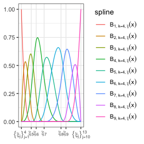

```r
bmat <- bsplines(x = seq(0, 6, length = 500), iknots = c(1.0, 1.5, 2.3, 4.0, 4.5))
plot(bmat)
```

# Topics to be written:

- Construction of control polygons, `cp`
- Tensor products, in general `build_tensor` and of B-splines `btensor`
- Construction of control nets, `cn`
- Assessing the relative influence of a knot
- Plotting splines and surfaces

# Session Info

```r
print(sessionInfo(), local = FALSE)
## R version 4.3.2 (2023-10-31)
## Platform: x86_64-apple-darwin20 (64-bit)
## Running under: macOS Monterey 12.6
##
## Matrix products: default
## BLAS:   /Library/Frameworks/R.framework/Versions/4.3-x86_64/Resources/lib/libRblas.0.dylib
## LAPACK: /Library/Frameworks/R.framework/Versions/4.3-x86_64/Resources/lib/libRlapack.dylib;  LAPACK version 3.11.0
##
## attached base packages:
## [1] splines   stats     graphics  grDevices utils     datasets  methods
## [8] base
##
## other attached packages:
## [1] cpr_0.3.0  knitr_1.45
##
## loaded via a namespace (and not attached):
##  [1] Matrix_1.6-3     gtable_0.3.4     jsonlite_1.8.7   highr_0.10
##  [5] dplyr_1.1.4      compiler_4.3.2   tidyselect_1.2.0 Rcpp_1.0.11
##  [9] jquerylib_0.1.4  scales_1.2.1     boot_1.3-28.1    yaml_2.3.7
## [13] fastmap_1.1.1    lattice_0.22-5   ggplot2_3.4.4    R6_2.5.1
## [17] labeling_0.4.3   generics_0.1.3   MASS_7.3-60      tibble_3.2.1
## [21] nloptr_2.0.3     munsell_0.5.0    minqa_1.2.6      bslib_0.6.0
## [25] pillar_1.9.0     rlang_1.1.2      utf8_1.2.4       cachem_1.0.8
## [29] xfun_0.41        sass_0.4.7       cli_3.6.1        withr_2.5.2
## [33] magrittr_2.0.3   digest_0.6.33    grid_4.3.2       lme4_1.1-35.1
## [37] lifecycle_1.0.4  nlme_3.1-163     vctrs_0.6.4      evaluate_0.23
## [41] glue_1.6.2       farver_2.1.1     fansi_1.0.5      colorspace_2.1-0
## [45] rmarkdown_2.25   tools_4.3.2      pkgconfig_2.0.3  htmltools_0.5.7
```